# 9096_Samyukhthaa_CA2

## Samyukhthaa 9096 TYCS B

CA2

### A. Data Preparation Questions (1–12)

```python
import pandas as pd
import numpy as np
import matplotlib.pyplot as plt
import seaborn as sns
from google.colab import drive
drive.mount('/content/drive')
```

```python
path="/content/9096_Samyukhthaa_student_placement.csv"
df = pd.read_csv(path)

# display first 5 rows
df.head()
```

|  | student_id | gender | ssc_percentage | hsc_percentage | degree_percentage | cgpa | entrance_exam_score | technical_skill_score | soft_skill_score | internship_count | live_projects | work_experience_months | certifications | attendance_percentage | backlogs | extracurricular_activities | placement_status | salary_package_lpa |
| --- | --- | --- | --- | --- | --- | --- | --- | --- | --- | --- | --- | --- | --- | --- | --- | --- | --- | --- |
| 0 | 1 | Male | 53 | 79 | 56 | 8.87 | 50 | 92 | 90 | 1 | 3 | 23 | 4 | 91 | 4 | Yes | 0 | 0.00 |
| 1 | 2 | Female | 56 | 54 | 59 | 6.78 | 61 | 51 | 99 | 1 | 0 | 6 | 5 | 87 | 3 | No | 0 | 0.00 |
| 2 | 3 | Male | 94 | 83 | 83 | 7.92 | 91 | 93 | 84 | 1 | 1 | 10 | 2 | 81 | 2 | No | 1 | 6.92 |
| 3 | 4 | Male | 84 | 71 | 87 | 6.57 | 85 | 60 | 72 | 4 | 2 | 14 | 5 | 87 | 3 | No | 0 | 0.00 |
| 4 | 5 | Male | 58 | 88 | 74 | 9.01 | 73 | 52 | 88 | 1 | 2 | 20 | 0 | 60 | 1 | No | 0 | 0.00 |

1. Find the total number of students and attributes in the dataset.

```python
df.shape
print("Total Students:", df.shape[0])
print("Total Attributes:", df.shape[1])
```

```
Total Students: 5000
Total Attributes: 18
```

2. Identify the data type of each column and classify them as numerical or categorical.

```python
df.dtypes
```

|  | 0 |
| --- | --- |
| student_id | int64 |
| gender | object |
| ssc_percentage | int64 |
| hsc_percentage | int64 |
| degree_percentage | int64 |
| cgpa | float64 |
| entrance_exam_score | int64 |
| technical_skill_score | int64 |
| soft_skill_score | int64 |
| internship_count | int64 |
| live_projects | int64 |
| work_experience_months | int64 |
| certifications | int64 |
| attendance_percentage | int64 |
| backlogs | int64 |
| extracurricular_activities | object |
| placement_status | int64 |
| salary_package_lpa | float64 |

**dtype:** object

3. Check for missing or null values in all columns.

```python
df.isnull().sum()
```

|  | 0 |
| --- | --- |
| student_id | 0 |
| gender | 0 |
| ssc_percentage | 0 |
| hsc_percentage | 0 |
| degree_percentage | 0 |
| cgpa | 0 |
| entrance_exam_score | 0 |
| technical_skill_score | 0 |
| soft_skill_score | 0 |
| internship_count | 0 |
| live_projects | 0 |
| work_experience_months | 0 |
| certifications | 0 |
| attendance_percentage | 0 |
| backlogs | 0 |
| extracurricular_activities | 0 |
| placement_status | 0 |
| salary_package_lpa | 0 |

**dtype:** int64

4. Verify whether percentages (ssc_percentage, hsc_percentage, degree_percentage, attendance_percentage) fall within valid ranges (0–100).

```python
percentage_cols = [
    'ssc_percentage',
    'hsc_percentage',
    'degree_percentage',
    'attendance_percentage'
]

for col in percentage_cols:
    invalid = df[(df[col] < 0) | (df[col] > 100)]
    print(f"{col} invalid entries:", invalid.shape[0])
```

```
ssc_percentage invalid entries: 0
hsc_percentage invalid entries: 0
degree_percentage invalid entries: 0
attendance_percentage invalid entries: 0
```

5. Detect duplicate student records using student_id.

```python
df[df.duplicated(subset='student_id')]
```

|  | student_id | gender | ssc_percentage | hsc_percentage | degree_percentage | cgpa | entrance_exam_score | technical_skill_score | soft_skill_score | internship_count | live_projects | work_experience_months | certifications | attendance_percentage | backlogs | extracurricular_activities | placement_status | salary_package_lpa |
| --- | --- | --- | --- | --- | --- | --- | --- | --- | --- | --- | --- | --- | --- | --- | --- | --- | --- | --- |

6. Convert categorical variables such as gender, extracurricular_activities, and placement_status into numerical form.

```python
from sklearn.preprocessing import LabelEncoder

le = LabelEncoder()

categorical_encode = [
    'gender',
    'extracurricular_activities',
    'placement_status'
]

for col in categorical_encode:
    df[col] = le.fit_transform(df[col])
```

7. Identify students with zero internships AND zero live projects

```python
zero_exp_students = df[
    (df['internship_count'] == 0) & (df['live_projects'] == 0)
]

zero_exp_students.shape[0]
```

```
178
```

8. Check inconsistent values in backlogs and work experience

```python
df[(df['backlogs'] < 0) | (df['work_experience_months'] < 0)]
```

|  | student_id | gender | ssc_percentage | hsc_percentage | degree_percentage | cgpa | entrance_exam_score | technical_skill_score | soft_skill_score | internship_count | live_projects | work_experience_months | certifications | attendance_percentage | backlogs | extracurricular_activities | placement_status | salary_package_lpa |
| --- | --- | --- | --- | --- | --- | --- | --- | --- | --- | --- | --- | --- | --- | --- | --- | --- | --- | --- |

9. Create a new feature called academic_average using SSC, HSC, and Degree percentages.

```python
df['academic_average'] = (
    df['ssc_percentage'] +
    df['hsc_percentage'] +
    df['degree_percentage']
) / 3
```

10. Normalize skill-related features (technical_skill_score, soft_skill_score).

```python
from sklearn.preprocessing import MinMaxScaler

scaler = MinMaxScaler()

skill_cols = ['technical_skill_score', 'soft_skill_score']
df[skill_cols] = scaler.fit_transform(df[skill_cols])
```

11. Create a binary feature employability_score based on skills, internships, and certifications.

```python
df['employability_score'] = (
    (df['technical_skill_score'] >= 0.5) &
    (df['soft_skill_score'] >= 0.5) &
    (df['internship_count'] >= 1) &
    (df['certifications'] >= 1)
).astype(int)
```

12. Prepare the final cleaned dataset and document all preprocessing steps.

```python
df.head()
```

|  | student_id | gender | ssc_percentage | hsc_percentage | degree_percentage | cgpa | entrance_exam_score | technical_skill_score | soft_skill_score | internship_count | live_projects | work_experience_months | certifications | attendance_percentage | backlogs | extracurricular_activities | placement_status | salary_package_lpa | academic_average | employability_score |
| --- | --- | --- | --- | --- | --- | --- | --- | --- | --- | --- | --- | --- | --- | --- | --- | --- | --- | --- | --- | --- |
| 0 | 1 | 1 | 53 | 79 | 56 | 8.87 | 50 | 0.881356 | 0.847458 | 1 | 3 | 23 | 4 | 91 | 4 | 1 | 0 | 0.00 | 62.666667 | 1 |
| 1 | 2 | 0 | 56 | 54 | 59 | 6.78 | 61 | 0.186441 | 1.000000 | 1 | 0 | 6 | 5 | 87 | 3 | 0 | 0 | 0.00 | 56.333333 | 0 |
| 2 | 3 | 1 | 94 | 83 | 83 | 7.92 | 91 | 0.898305 | 0.745763 | 1 | 1 | 10 | 2 | 81 | 2 | 0 | 1 | 6.92 | 86.666667 | 1 |
| 3 | 4 | 1 | 84 | 71 | 87 | 6.57 | 85 | 0.338983 | 0.542373 | 4 | 2 | 14 | 5 | 87 | 3 | 0 | 0 | 0.00 | 80.666667 | 0 |
| 4 | 5 | 1 | 58 | 88 | 74 | 9.01 | 73 | 0.203390 | 0.813559 | 1 | 2 | 20 | 0 | 60 | 1 | 0 | 0 | 0.00 | 73.333333 | 0 |

### B. Exploratory Data Analysis (13–25)

13. Gender-wise distribution

```python
df['gender'].value_counts()
```

| gender | count |
| --- | --- |
| 1 | 2504 |
| 0 | 2496 |

**dtype:** int64

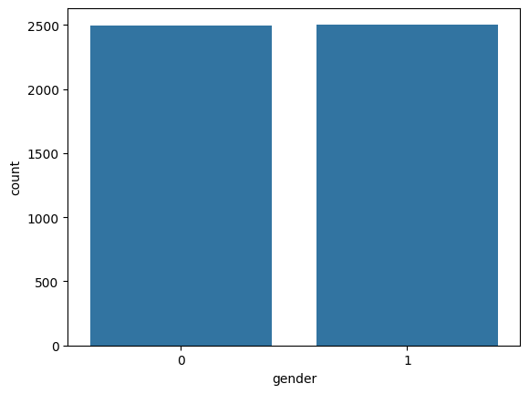

```python
sns.countplot(x='gender', data=df)
plt.show()
```

14. CGPA comparison (Placed vs Not Placed)

```python
df.groupby('placement_status')['cgpa'].mean()
```

| placement_status | cgpa |
| --- | --- |
| 0 | 7.520525 |
| 1 | 8.431617 |

**dtype:** float64

15. Study the relationship between technical skills and placement status.

```python
df.groupby('placement_status')['technical_skill_score'].mean()
```

| placement_status | technical_skill_score |
| --- | --- |
| 0 | 0.469701 |
| 1 | 0.659412 |

**dtype:** float64

16. Analyze how soft skills influence placement outcomes.

```python
df.groupby('placement_status')['soft_skill_score'].mean()
```

| placement_status | soft_skill_score |
| --- | --- |
| 0 | 0.479427 |
| 1 | 0.631444 |

**dtype:** float64

17. Compare the average entrance exam score of placed vs non-placed students.

```python
df.groupby('placement_status')['entrance_exam_score'].mean()
```

| placement_status | entrance_exam_score |
| --- | --- |
| 0 | 69.190373 |
| 1 | 69.233256 |

**dtype:** float64

18. Analyze the impact of internship count on placement.

```python
df.groupby('placement_status')['internship_count'].mean()
```

| placement_status | internship_count |
| --- | --- |
| 0 | 1.980648 |
| 1 | 2.021940 |

**dtype:** float64

19. Study the relationship between live projects and salary_package_lpa.

```python
df[['live_projects','salary_package_lpa']].corr()
```

|  | live_projects | salary_package_lpa |
| --- | --- | --- |
| live_projects | 1.000000 | -0.003859 |
| salary_package_lpa | -0.003859 | 1.000000 |

20. Analyze whether attendance percentage affects placement chances.

```python
df.groupby('placement_status')['attendance_percentage'].mean()
```

| placement_status | attendance_percentage |
| --- | --- |
| 0 | 79.497581 |
| 1 | 79.127021 |

**dtype:** float64

21. Examine the effect of backlogs on placement status.

```python
df.groupby('placement_status')['backlogs'].mean()
```

| placement_status | backlogs |
| --- | --- |
| 0 | 2.834543 |
| 1 | 1.009238 |

**dtype:** float64

22. Identify which certification count range has the highest placement rate.

```python
pd.crosstab(df['certifications'], df['placement_status'])
```

| placement_status certifications | 0 | 1 |
| --- | --- | --- |
| 0 | 724 | 142 |
| 1 | 690 | 136 |
| 2 | 688 | 163 |
| 3 | 657 | 130 |
| 4 | 680 | 154 |
| 5 | 695 | 141 |

23. Perform correlation analysis among academic, skill, and experience variables.

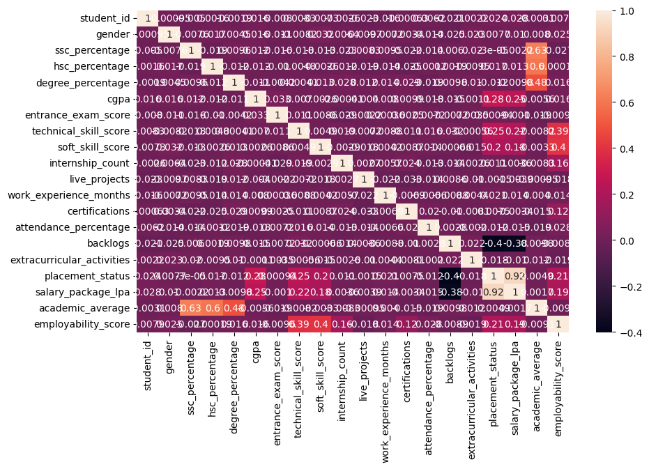

```python
plt.figure(figsize=(10,6))
sns.heatmap(df.corr(), annot=True)
plt.show()
```

24. Identify the top 5 features influencing placement based on EDA.

```python
df.corr()['placement_status'].sort_values(ascending=False)[1:6]
```

|  | placement_status |
| --- | --- |
| salary_package_lpa | 0.923552 |
| cgpa | 0.278728 |
| technical_skill_score | 0.246573 |
| employability_score | 0.210702 |
| soft_skill_score | 0.197685 |

**dtype:** float64

MODEL TRAINING

Import ML libraries

```python
from sklearn.model_selection import train_test_split
from sklearn.linear_model import LinearRegression
from sklearn.metrics import mean_absolute_error, mean_squared_error
import numpy as np
```

```python
# Select input features
X = df[['academic_average',
        'technical_skill_score',
        'soft_skill_score',
        'internship_count',
        'certifications',
        'attendance_percentage',
        'backlogs']]

# Target variable
y = df['salary_package_lpa']

print("Feature Selection Completed")
```

```
Feature Selection Completed
```

Train Test Split (THIS CREATES X_train, X_test, y_train, y_test)

```python
X_train, X_test, y_train, y_test = train_test_split(
    X, y, test_size=0.2, random_state=42
)

print("Train-Test Split Completed")
```

```
Train-Test Split Completed
```

Linear Regression Model

```python
model = LinearRegression()
model.fit(X_train, y_train)

print("Linear Regression Model Trained")
```

```
Linear Regression Model Trained
```

Prediction

```python
y_pred = model.predict(X_test)

print("Prediction Completed")
y_pred
```

```
Prediction Completed
```

[output not shown]

[output cut: 195 more lines]

[output not shown]

```python
X_test
```

|  | academic_average | technical_skill_score | soft_skill_score | internship_count | certifications | attendance_percentage | backlogs |
| --- | --- | --- | --- | --- | --- | --- | --- |
| 1501 | 80.000000 | 0.576271 | 0.186441 | 4 | 1 | 85 | 3 |
| 2586 | 75.333333 | 0.237288 | 0.271186 | 0 | 0 | 74 | 3 |
| 2653 | 67.000000 | 0.271186 | 0.864407 | 3 | 1 | 93 | 1 |
| 1055 | 75.333333 | 0.610169 | 0.288136 | 0 | 2 | 94 | 1 |
| 705 | 68.333333 | 0.915254 | 0.067797 | 2 | 5 | 60 | 1 |
| ... | ... | ... | ... | ... | ... | ... | ... |
| 4711 | 70.333333 | 0.491525 | 1.000000 | 1 | 4 | 70 | 2 |
| 2313 | 58.333333 | 0.135593 | 0.949153 | 4 | 5 | 70 | 2 |
| 3214 | 63.000000 | 0.915254 | 0.203390 | 0 | 3 | 94 | 1 |
| 2732 | 65.000000 | 0.932203 | 0.576271 | 3 | 4 | 84 | 0 |
| 1926 | 80.000000 | 0.457627 | 0.322034 | 4 | 4 | 84 | 0 |

1000 rows × 7 columns

```python
X_train
```

|  | academic_average | technical_skill_score | soft_skill_score | internship_count | certifications | attendance_percentage | backlogs |
| --- | --- | --- | --- | --- | --- | --- | --- |
| 4227 | 67.000000 | 0.830508 | 0.220339 | 1 | 0 | 84 | 3 |
| 4676 | 88.333333 | 0.406780 | 0.949153 | 2 | 0 | 80 | 2 |
| 800 | 77.666667 | 0.203390 | 0.169492 | 4 | 4 | 86 | 3 |
| 3671 | 70.666667 | 0.067797 | 0.423729 | 1 | 0 | 76 | 4 |
| 4193 | 58.666667 | 0.084746 | 0.966102 | 2 | 0 | 93 | 0 |
| ... | ... | ... | ... | ... | ... | ... | ... |
| 4426 | 66.333333 | 0.406780 | 0.728814 | 3 | 5 | 74 | 4 |
| 466 | 77.666667 | 0.966102 | 0.762712 | 3 | 4 | 82 | 3 |
| 3092 | 74.666667 | 0.203390 | 0.576271 | 1 | 2 | 72 | 4 |
| 3772 | 71.000000 | 0.118644 | 0.932203 | 3 | 1 | 99 | 0 |
| 860 | 63.000000 | 0.237288 | 0.711864 | 4 | 0 | 67 | 1 |

4000 rows × 7 columns

```python
y_train
```

|  | salary_package_lpa |
| --- | --- |
| 4227 | 0.00 |
| 4676 | 8.21 |
| 800 | 0.00 |
| 3671 | 0.00 |
| 4193 | 0.00 |
| ... | ... |
| 4426 | 0.00 |
| 466 | 0.00 |
| 3092 | 0.00 |
| 3772 | 0.00 |
| 860 | 0.00 |

4000 rows × 1 columns

**dtype:** float64

```python
y_test
```

|  | salary_package_lpa |
| --- | --- |
| 1501 | 0.00 |
| 2586 | 0.00 |
| 2653 | 0.00 |
| 1055 | 0.00 |
| 705 | 0.00 |
| ... | ... |
| 4711 | 0.00 |
| 2313 | 0.00 |
| 3214 | 0.00 |
| 2732 | 14.84 |
| 1926 | 14.27 |

1000 rows × 1 columns

**dtype:** float64

Model Evaluation

```python
mae = mean_absolute_error(y_test, y_pred)
mse = mean_squared_error(y_test, y_pred)
rmse = np.sqrt(mse)

print("MAE:", mae)
print("MSE:", mse)
print("RMSE:", rmse)
```

```
MAE: 2.33548154030338
MSE: 11.174665776571848
RMSE: 3.34285293971659
```

```python
!ls
```

```
9096_Samyukhthaa_student_placement.csv	drive  sample_data
```

```python
!jupyter nbconvert --to html 9096_Samyukhthaa_CA2.ipynb
```

[output not shown]

[output cut: 136 more lines]

[output not shown]